# White wine properties and quality by M. Joukamaa

# Multivariate Analysis

Most of the scatter plots I made above don’t really present any discernible patterns of trivariate relationships between the two variables plotted and the grouping made by expert ratings. While in some of the plots the best-rated wines are clearly concentrated in a certain end of one of the axes, the expert ratings tend to be all over the place in terms of the other plotted variable. The numerous outliers present in the volatile acidity and chloride distributions that were noted previously account undoubtedly for a lot of this noise. Still, the lack of discernible patterns in most of the above plots doesn’t probably return exclusively to the effect of the outliers.

However, the scatter plot of total sulfur dioxide amount versus alcohol content seems to show a clear and discernible relationship between the three different variables examined. The best-rated wines are concentrated mostly not only in the high end of the alcohol volume scale but also in the lower ratings of total sulfur dioxide amount. Thus, according to these results, in order for a wine to achieve a good expert rating it needs to have a relatively high alcohol volume, but the amount of sulfur dioxide in it should also be rather low.

# Final Plots and Summary

### Plot One

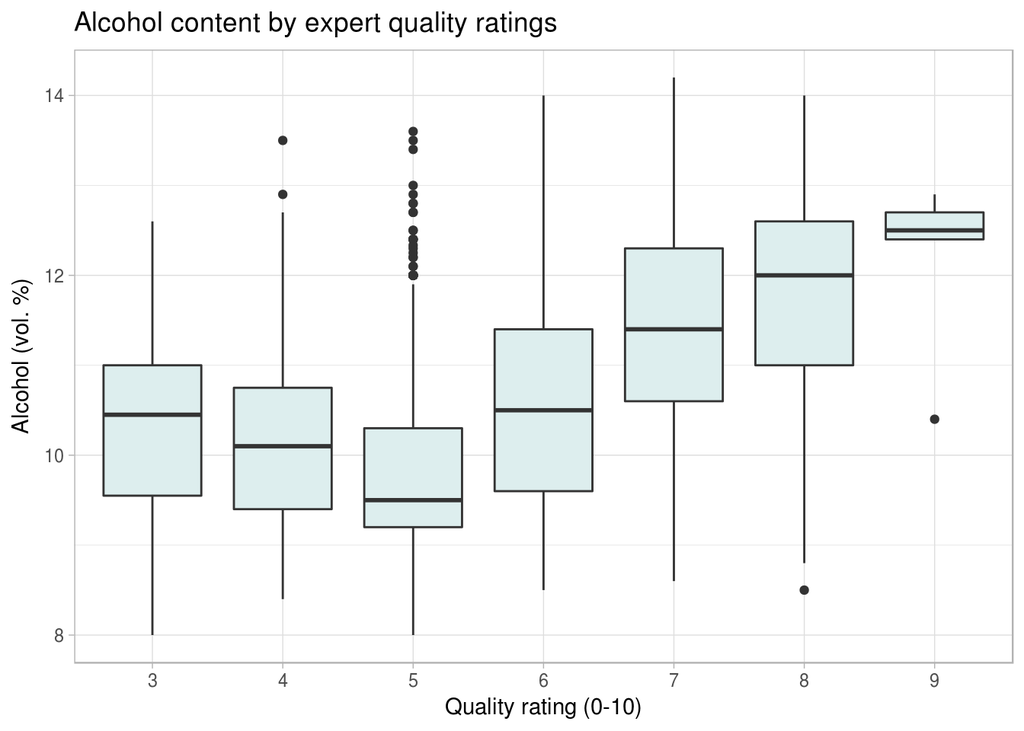

### Description One

The plot above shows a strong and clear relationship between the alcohol content of the wine samples and expert ratings given to them. This relationship is not entirely straightforward, though. As can be seen in the plot, there is a slight upward trend in the alcohol content of the samples toward the lower range of the ratings scale as well. But in general it can be said that wine samples with higher alcohol content tend to also get higher expert ratings.

### Plot Two

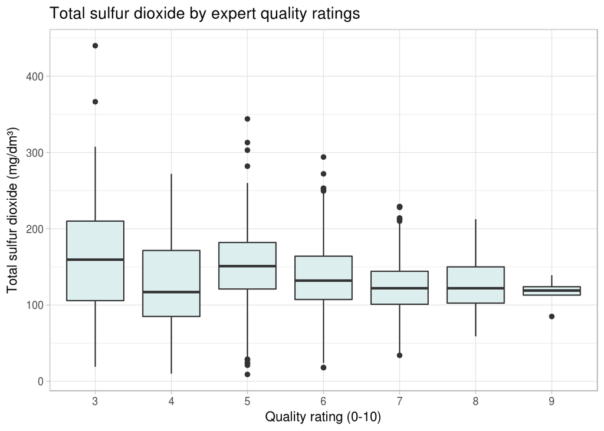

### Description Two

This second plot show that for the total amount of sulfur dioxide in the samples the higher ratings are associated with a downward trend for the sulfur dioxide. Even though there can be seen some slight fluctuation in the plot, the overall trend is quite clear.

### Plot Three

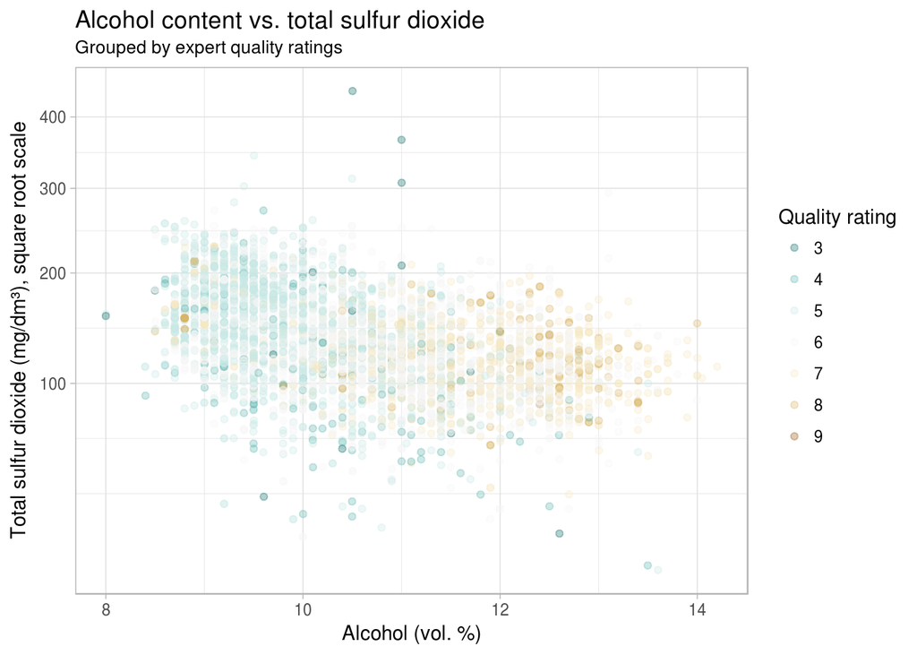

# Reflection

In this report I set out to examine a dataset of 4898 wine samples with 13 different variables measuring the chemical and physical qualities of the samples as well as rating them on their overall quality. I looked over the distributions of the individual variables and then focused more closely on how the different chemical and physical qualities were associated with quality ratings of the samples. In the end, I found a rather clear and straightforward three-way relationship between the sample ratings, their alcohol content and the total amount of sulfur dioxide in them.

It was somewhat sobering (pun intended) to see how strongly the alcohol content was correlated with the ratings given to the samples by wine-tasting experts, as even these experts seem to mostly favor strong wines over lighter ones. While some of the other objective properties of the wine samples were also associated with the expert rating levels to some degree, the negative relationship with the total amount of sulfur dioxide provided a particularly distinguishable fit when coupled with the alcohol content.

The examination of the dataset was mostly a rather straightforward job, though of course time-consuming in nature. Probably the most vexing part of the examination was figuring out which of the bivariate relationships were significant enough to warrant further investigation. Stylistical considerations for the three summary plots necessitated also several trial-and-error iterations before arriving to their final designs.

While further analyses about the relationships between the different chemical and physical properties of the samples can always be made, more fruitful work on the samples would probably benefit from additional data. For example, information about grape strains used or fermentation times and conditions could probably provide all kinds of interesting insights when combined with the current data. Another possible avenue of investigation would be to look at the prices of the different wines and how much they correlate on one hand with the expert ratings, and on the other hand with the most significant chemical and physical properties of the samples.